# Non-disclosive federated omic data analysis with DataSHIELD and Bioconductor

Yannick Marcon and Juan R. Gonzalez

Epigeny  
Bioinformatics Research Group in Epidemiolgy (BRGE), Barcelona Insitute for Global Health (ISGlobal)  
Department of Mathematics, Autonomous University of Barcelona (UAB)

yannick.marcon@obiba.org  
juanr.gonzalez@isglobal.org

2021-05-12

2021-05-10

#### Package

dsOmics 1.0.5.1

# 1 Purpose

The purpose of the *dsOmicsClient* package is to provide a set of functions to perform omic association analyses when data are stored on federated databases or, more generally, in different repositories. In particular the package utilizes DataSHIELD infrastructure which is a software solution that allows simultaneous co-analysis of data from multiple studies stored on different servers without the need to physically pool data or disclose sensitive information (Wilson et al. 2017). DataSHIELD uses [Opal servers](http://opaldoc.obiba.org/en/latest/) to properly perform such analyses. [Our bookdown](https://isglobal-brge.github.io/resource_bookdown/dslite-datashield-implementation-on-local-datasets.html) introduces Opal, DaaSHIELD and other related features. Here, we describe the most relevant ones to be able to reproduce this document.

At a high level DataSHIELD is set up as a client-server model which houses the data for a particular study. A request is made from the client to run specific functions on the remote servers where the analysis is performed. Non-sensitive and pre-approved summary statistics are returned from each study to the client where they can be combined for an overall analysis. An overview of what a single-site DataSHIELD architecture would look like is illustrated in Figure 1.

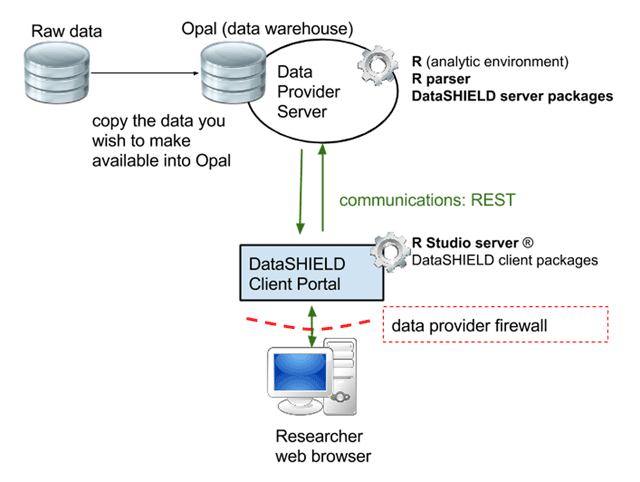

Figure 1: Single Server DataSHIELD Architecture (Wilson et al 2017)

One of the main limitations of DataSHIELD is how to deal with large data given the restrictions of Opal with databases. Nonetheless, the recent development of the *resourcer* R package allows DataSHIELD developers to overcome this drawback by granting the Opal servers to deal with any type of data (e.g. **resources**). So far, Opal can register access to different types of data resources in different formats (csv, tsv, R data, SQL, tiddy, ..) that can also be located in different places (local, http, ssh, AWS S3 or Mongodb file stores, …). This is another important advancement since the *resourcer* addresses another important issue that is having duplicated data in different research centers or hospitals.

The *resourcer* package permits to work with specific R data classes. This is highly important in our setting since it will allow to use [Bioconductor](http://www.bioconductor.org) classes to properly manage omic data using efficient infrastructures such as `ExpressionSet` or `RangedSummarizedExperiment` among others. Another important asset of the *resourcer* package is that it can be extended to new data types by writting specific functions (see [how to extending resources](https://github.com/obiba/resourcer/#extending-resources). We have used this feature and created some functions for the analysis of [Variant Calling Format](https://en.wikipedia.org/wiki/Variant_Call_Format) (VCF files) that are loaded into R as [Genomic Data Storage](https://bioconductor.org/packages/release/bioc/vignettes/gdsfmt/inst/doc/gdsfmt.html#introduction) objects. These functions along with others that allow the managment of Bioconductor classes in DataSHIELD have been included in a new DataSHIELD package, the *dsOmics*, which is able to manage different [Bioconductor](http://www.bioconductor.org) data infrastructures that are required to perform omic association analyses. These including `ExpressionSet`, `RangedSummarizedExperiment` or `GDS` among others. Generaly speaking, any data format and storage that can be read by R can be expressed as a **resource**.

In the next sections we first describe how to deal with Opal servers and resources. We illustre how we prepared a test environment to describe how Opal must be setup as well as how to provide the appropiate R/DataSHIELD configuration in both the Opal server and the client side to perform omic association analyses. Then, the different types of omic data analyses that can be performed with the *dsOmicsClient* functionality are described and further illustrated using real data examples including epigenome, transcriptome and genomic data analyses.

# 2 Setup

In this section we describe how to configure the Opal server and the needed packages to carry out omic association analyses from the client side. Basically, the resources must be defined in the Opal along with the required information that includes the url where data is located, the format (e.g., SPSS, R class, GDS …) and the credentials which are not visible to the DataSHIELD users (Figure 2). The permission to use a resource for DataSHIELD operations is granted (to a user or a group of users) in Opal.

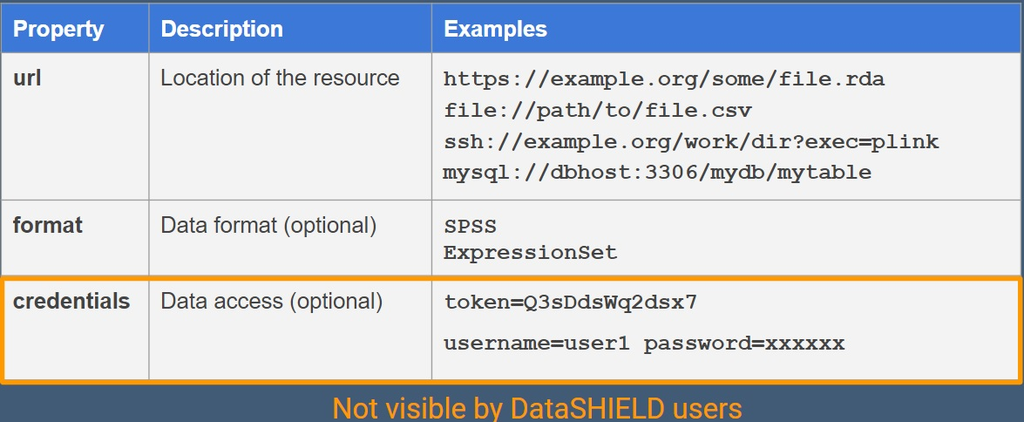

Figure 2: Information required for Resources

A description of the pre-requisites can be found [here](https://datashield.discourse.group/t/datashield-resources/152). At the time of the writing of this vignette, the resource capabilities of Opal, DataSHIELD and related R packages have not been released yet. Basically, what is needed is:

- *DSI*
- *DSOpal*
- *opalr*
- OPTIONAL (used for development): *DSLite*
- *dsBaseClient* in the v6.0-dev branch
- *dsOmicsClient*

and in the server side: - *resourcer* - *dsOmics* - *dsBase* in the v6.0-dev branch

Notice that the *dsOmics* package includes new extensions of the *resourcer* package to deal with new types of resources such as file in VCF format to converted to a file in GDS format (VCF2GDS). Next subsections further describe what is required along with some examples.

## 2.1 Required Opal server with resources

Resources are datasets or computation units which are located under a URL and their access is protected by some credentials. When resources are assigned to a R/DataSHIELD server session, remote big/complex datasets or high performance computers are being accessible to data analysts.

Instead of storing the data in Opal databases, only the way to access them needs to be defined: the datasets are kept in their original format and location (e.g., an R object, a SQL database, a SPSS file, etc.) and are read directly from the R/DataSHIELD server-side session. Then as soon as there is a R reader for the dataset or a connector for the analysis services, a resource can be defined. Opal takes care of the DataSHIELD permissions (a DataSHIELD user cannot see the resource’s credentials) and of the resources assignment to a R/DataSHIELD session (see Figure 3)

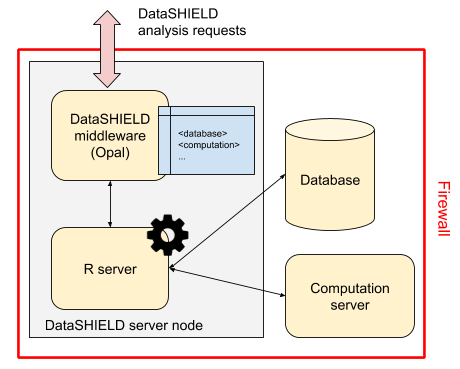

Figure 3: Resources: a new DataSHIELD infrastructure

As previously mentioned, the `resourcer` R package allows to deal with the main data sources (using tidyverse, DBI, dplyr, sparklyr, MongoDB, AWS S3, SSH etc.) and is easily extensible to new ones including specific data infrastructure in R or Bioconductor. So far `ExpressionSet` and `RangedSummarizedExperiment` objects saved in `.rdata` files are accesible through the `resourcer` package. The `dsOmics` package contains a new extension that deals with VCF (Variant Calling Format) files which are coerced to a GDS (Genomic Data Storage) format (VCF2GDS).

In order to achive this `resourcer` extension, two `R6` classes have been implemented:

- `GDSFileResourceResolver` class which handles file-base resources with data in GDS or VCF formats. This class is responsible for creating a `GDSFileResourceClient` object instance from an assigned resource.
- `GDSFileResourceClient` class which is responsible for getting the referenced file and making a connection (created by `GWASTools`) to the GDS file (will also convert the VCF file to a GDS file on the fly, using `SNPRelate`). For the subsequent analysis, it’s this connection handle to the GDS file that will be used.

We have prepared a test environment, with the Opal implementation of Resources and an appropriate R/DataSHIELD configuration that is available at: opal-demo.obiba.org. This figure illustrate the resources which are available for the `RSRC` project:

[figure not shown]

Figure 4: Resources from a test enviroment available at https://opal-demo.obiba.org

It is possible to declare a resource that is to be resolved by an R package that uses the `resourcer` API

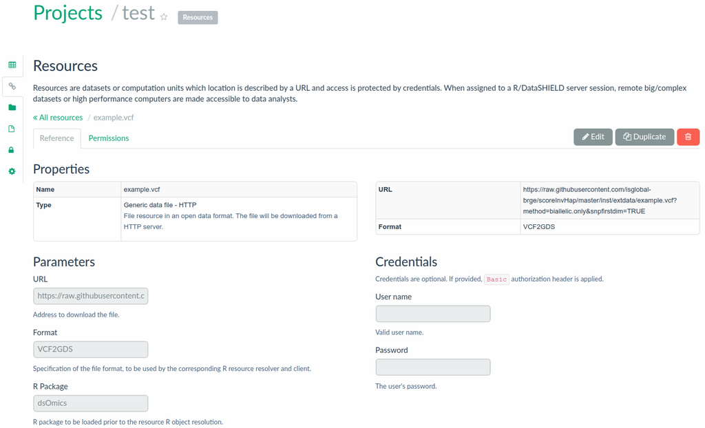

Figure 5: Declaration of a resource corresponding to a VCF2GDS format

## 2.2 Required DataSHIELD packages in the opal server

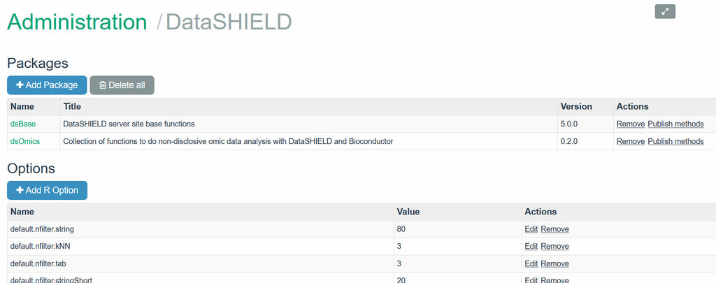

Figure 6: Installed packages in the test opal server

The tab **+Add package** can be used to install a new package. The figure depicts how `dsOmics` was intalled into the opal server

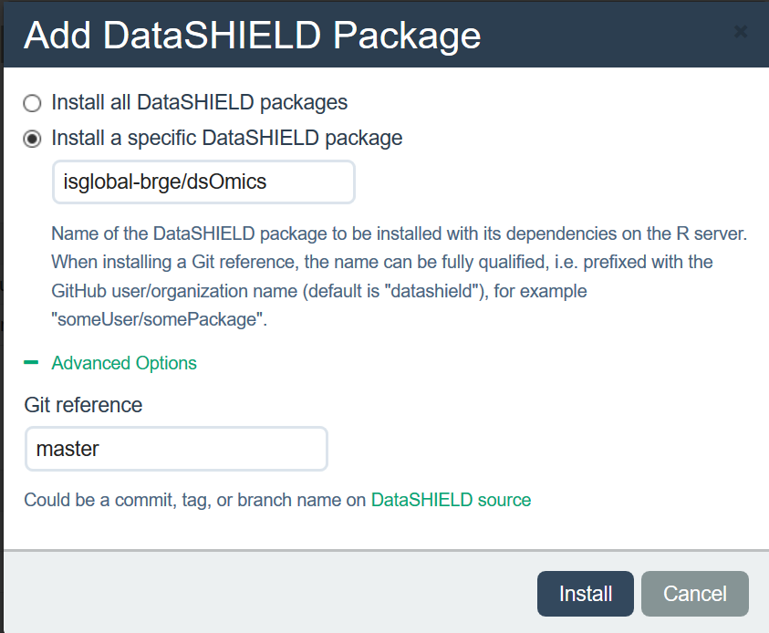

Figure 7: Description how `dsOmics` package was intalled into the test opal server

## 2.3 Required R Packages in the client site (e.g. local machine)

In order to use the functions contained within this package the following R packages must be installed in the client side:

```r
install.packages("DSIOpal")
install.packages('dsBaseClient', repos=c(getOption('repos'),
                                         'http://cran.obiba.org'), dependencies=TRUE)
devtools::install_github("isglobal-brge/dsOmicsClient", dependencies = TRUE)
```

The package dependencies are then loaded as follows:

```r
library(DSOpal)
library(dsBaseClient)
library(dsOmicsClient)
```

**Notes**:

For advanced users willing to use `DSLite`, the server side packages needs to be installed as well:

```r
install.packages(c("resourcer", "DSLite"), dependencies = TRUE)
install.packages("dsBase", repos = c("https://cloud.r-project.org",
                                     "https://cran.obiba.org"), dependencies = TRUE)
```

We refer to [this chapter](https://isglobal-brge.github.io/resource_bookdown/dslite-datashield-implementation-on-local-datasets.html) of our bookdown to a more detail description about how to work with DataSHIELD in a serverless environment.

# 3 Transcriptomic and Epigenomic data analysis

## 3.1 Single study analysis

Let us start by illustrating a simple example where a researcher may be interested in performing differential gene expression analysis (DGE) having data in a single repository (e.g. one study).

### 3.1.1 Illustrative example: differential gene expression (DGE) analysis

Let us illustrate how to perform transcriptomic data analysis using data from [TCGA project](https://www.cancer.gov/about-nci/organization/ccg/research/structural-genomics/tcga). We have uploaded to the opal server a resource called `tcga_liver` whose URL is http://duffel.rail.bio/recount/TCGA/rse_gene_liver.Rdata which is available through the [recount project](https://jhubiostatistics.shinyapps.io/recount/). This resource contains the `RangeSummarizedExperiment` with the RNAseq profiling of liver cancer data from TCGA. Next, we illustrate how a differential expression analysis to compare RNAseq profiling of women vs men (variable `gdc_cases.demographic.gender`). The DGE analysis is normally performed using *limma* package. In that case, as we are analyzing RNA-seq data, `limma + voom` method will be required.

Let us start by creating the connection to the opal server:

```r
builder <- newDSLoginBuilder()
builder$append(server = "study1", url = "https://opal-demo.obiba.org",
               user = "dsuser", password = "password",
               resource = "RSRC.tcga_liver")

logindata <- builder$build()

conns <- datashield.login(logins = logindata, assign = TRUE,
                          symbol = "res")
```

Then, let us coerce the resource to a `RangedSummarizedExperiment` which is the type of object that is available in the [recount project](https://jhubiostatistics.shinyapps.io/recount/).

```r
datashield.assign.expr(conns, symbol = "rse",
                       expr = quote(as.resource.object(res)))
ds.class("rse")
```

```
$study1
[1] "RangedSummarizedExperiment"
attr(,"package")
[1] "SummarizedExperiment"
```

The number of features and samples can be inspected by

```r
ds.dim("rse")
```

```
$`dimensions of rse in study1`
[1] 58037   424

$`dimensions of rse in combined studies`
[1] 58037   424
```

And the names of the features using the same function used in the case of analyzing an `ExpressionSet`

```r
name.features <- ds.featureNames("rse")
lapply(name.features, head)
```

```
$study1
[1] "ENSG00000000003.14" "ENSG00000000005.5"
[3] "ENSG00000000419.12" "ENSG00000000457.13"
[5] "ENSG00000000460.16" "ENSG00000000938.12"
```

Also the covariate names can be inspected by

```r
name.vars <- ds.featureData("rse")
lapply(name.vars, head, n=15)
```

```
$study1
 [1] "project"
 [2] "sample"
 [3] "experiment"
 [4] "run"
 [5] "read_count_as_reported_by_sra"
 [6] "reads_downloaded"
 [7] "proportion_of_reads_reported_by_sra_downloaded"
 [8] "paired_end"
 [9] "sra_misreported_paired_end"
[10] "mapped_read_count"
[11] "auc"
[12] "sharq_beta_tissue"
[13] "sharq_beta_cell_type"
[14] "biosample_submission_date"
[15] "biosample_publication_date"
```

We can visualize the levels of the variable having gender information that will be our condition (i.e., we are interested in obtaining genes that are differentially expressed between males and females)

```r
ds.table("rse$gdc_cases.demographic.gender")
```

```
 Data in all studies were valid

Study 1 :  No errors reported from this study
```

```
$output.list
$output.list$TABLE_rvar.by.study_row.props
                                study
rse$gdc_cases.demographic.gender 1
                          female 1
                          male   1

$output.list$TABLE_rvar.by.study_col.props
                                study
rse$gdc_cases.demographic.gender         1
                          female 0.3372642
                          male   0.6627358

$output.list$TABLE_rvar.by.study_counts
                                study
rse$gdc_cases.demographic.gender   1
                          female 143
                          male   281

$output.list$TABLES.COMBINED_all.sources_proportions
rse$gdc_cases.demographic.gender
female   male
 0.337  0.663

$output.list$TABLES.COMBINED_all.sources_counts
rse$gdc_cases.demographic.gender
female   male
   143    281


$validity.message
[1] "Data in all studies were valid"
```

We have implemented a function called `ds.RNAseqPreproc()` to perform RNAseq data pre-processing that includes:

- transforming data into log2 CPM units
- filtering lowly-expressed genes
- data normalization

```r
ds.RNAseqPreproc('rse', group= 'gdc_cases.demographic.gender',
                 newobj.name = 'rse.pre')
```

Note that it is recommended to indicate the grouping variable (i.e., condition). Once data have been pre-processed, we can perform differential expression analysis. Notice how dimensions have changed given the fact that we have removed genes with low expression which are expected to do not be differentially expressed.

```r
ds.dim('rse')
```

```
$`dimensions of rse in study1`
[1] 58037   424

$`dimensions of rse in combined studies`
[1] 58037   424
```

```r
ds.dim('rse.pre')
```

```
$`dimensions of rse.pre in study1`
[1] 40363   424

$`dimensions of rse.pre in combined studies`
[1] 40363   424
```

The differential expression analysis is ´dsOmicsClient/dsOmics´ is implemented in the funcion `ds.limma()`. This functions runs a limma-pipeline for microarray data and for RNAseq data allows:

- voom + limma
- DESeq2
- edgeR

We recommend to use the `voom + limma` pipeline proposed [here](https://f1000research.com/articles/5-1438/v2) given its versatility and that `limma` is much faster than `DESeq2` and `edgeR`. By default, the function consider that data are obtained from a microarray experiment (`type.data = "microarray"`). Therefore, as we are analyzing RNAseq data, we much indicate that `type.data = "RNAse"`

```r
ans.gender <- ds.limma(model =  ~ gdc_cases.demographic.gender,
                       Set = "rse.pre", type.data = "RNAseq")
```

The top differentially expressed genes can be visualized by:

```r
ans.gender
```

```
$study1
# A tibble: 40,363 x 7
   id             n   beta     SE     t   P.Value adj.P.Val
   <chr>      <int>  <dbl>  <dbl> <dbl>     <dbl>     <dbl>
 1 ENSG00000~   424 -12.4  0.0761 -52.1 2.74e-187 1.11e-182
 2 ENSG00000~   424 -10.2  0.461  -43.8 5.21e-160 1.05e-155
 3 ENSG00000~   424 -11.0  0.0603 -39.5 1.08e-144 1.45e-140
 4 ENSG00000~   424 -11.3  0.0651 -36.0 2.27e-131 2.29e-127
 5 ENSG00000~   424  10.9  0.0885  35.5 1.85e-129 1.49e-125
 6 ENSG00000~   424  10.2  0.118   32.9 3.72e-119 2.50e-115
 7 ENSG00000~   424  11.4  0.128   31.9 5.57e-115 3.21e-111
 8 ENSG00000~   424  -7.78 0.0812 -28.8 3.85e-102 1.94e- 98
 9 ENSG00000~   424   9.62 0.0894  27.4 4.72e- 96 2.12e- 92
10 ENSG00000~   424  11.4  0.0924  27.3 9.63e- 96 3.89e- 92
# ... with 40,353 more rows

attr(,"class")
[1] "dsLimma" "list"
```

We can verify whether the distribution of the observed p-values are the ones we expect in this type of analyses

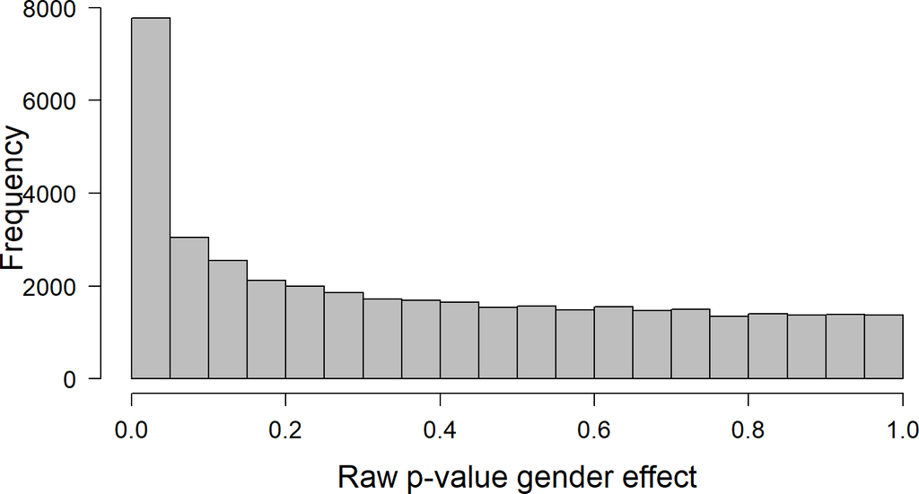

```r
hist(ans.gender$study1$P.Value, xlab="Raw p-value gender effect",
     main="", las=1, cex.lab=1.5, cex.axis=1.2, col="gray")
```

We can also check whether there is inflation just executing

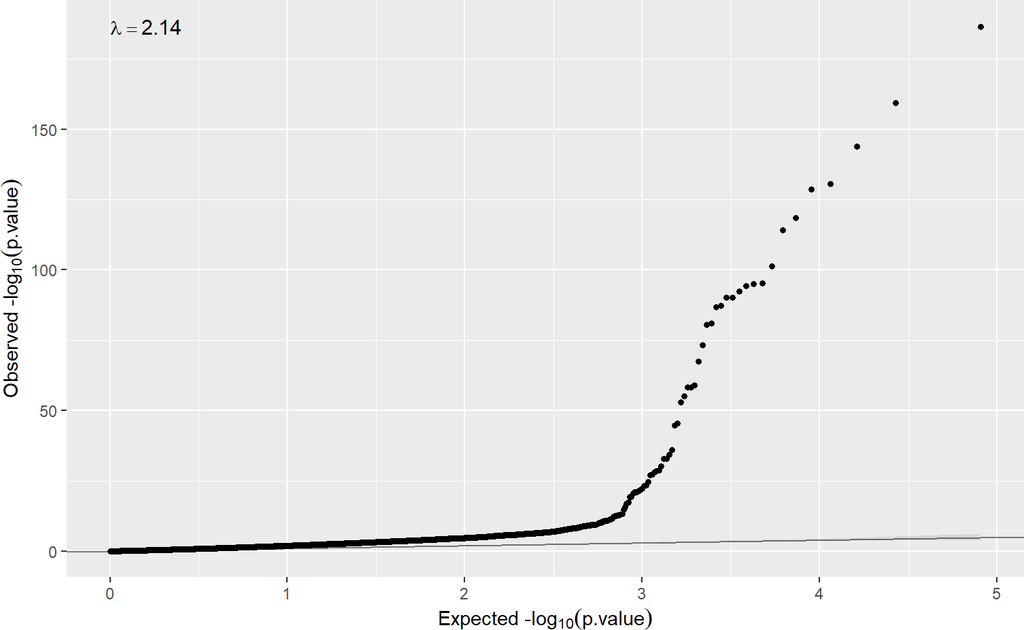

```r
qqplot(ans.gender$study1$P.Value)
```

So, in that case, the model needs to remove unwanted variability ($\lambda>2$). If so, we can use surrogate variable analysis just changing the argument `sva=TRUE`

```r
ans.gender.sva <- ds.limma(model =  ~ gdc_cases.demographic.gender,
                       Set = "rse.pre", type.data = "RNAseq",
                       sva = TRUE)
```

Now the inflation has dramatically been reduced ($\lambda>1.12$)

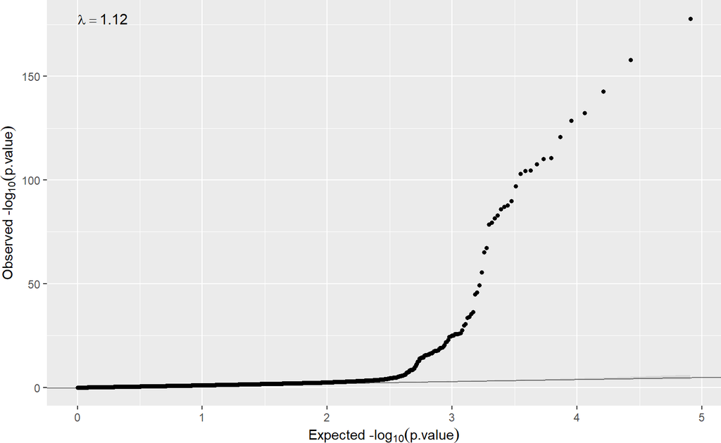

```r
qqplot(ans.gender.sva$study1$P.Value)
```

We can add annotation to the output that is available in our RSE object. We can have access to this information by

```r
ds.fvarLabels('rse.pre')
```

```
$study1
[1] "chromosome" "start"      "end"        "width"
[5] "strand"     "gene_id"    "bp_length"  "symbol"

attr(,"class")
[1] "dsfvarLabels" "list"
```

So, we can run

```r
ans.gender.sva <- ds.limma(model =  ~ gdc_cases.demographic.gender,
                       Set = "rse.pre", type.data = "RNAseq",
                       sva = TRUE, annotCols = c("chromosome"))
```

The results are:

```r
ans.gender.sva
```

```
$study1
# A tibble: 40,363 x 8
   id             n   beta     SE     t   P.Value adj.P.Val
   <chr>      <int>  <dbl>  <dbl> <dbl>     <dbl>     <dbl>
 1 ENSG00000~   424 -12.1  0.0713 -51.3 1.82e-178 7.33e-174
 2 ENSG00000~   424  -9.95 0.467  -44.9 1.52e-158 3.07e-154
 3 ENSG00000~   424 -10.7  0.0513 -40.3 2.19e-143 2.95e-139
 4 ENSG00000~   424 -10.7  0.0461 -37.4 6.78e-133 6.84e-129
 5 ENSG00000~   424  10.8  0.0571  36.4 2.43e-129 1.96e-125
 6 ENSG00000~   424  10.3  0.0774  34.3 1.98e-121 1.33e-117
 7 ENSG00000~   424   9.64 0.101   31.6 5.70e-111 2.87e-107
 8 ENSG00000~   424  11.2  0.0691  31.7 2.34e-111 1.35e-107
 9 ENSG00000~   424   4.48 0.0678  30.2 2.13e-105 8.61e-102
10 ENSG00000~   424  11.2  0.0547  30.9 2.17e-108 9.72e-105
# ... with 40,353 more rows, and 1 more variable:
#   chromosome <chr>

attr(,"class")
[1] "dsLimma" "list"
```

The function has another arguments that can be used to fit other type of models:

- sva: estimate surrogate variables
- annotCols: to add annotation available in the
- method: Linear regression (“ls”) or robust regression (“robust”) used in limma (`lmFit`)
- robust: robust method used for outlier sample variances used in limma (`eBayes`)
- normalization: normalization method used in the `voom` transformation (default “none”)
- voomQualityWeights: should `voomQualityWeights` function be used instead of `voom`? (default FALSE)
- big: should SmartSVA be used instead of SVA (useful for big sample size or when analyzing epigenome data. Default FALSE)

We close the DataSHIELD session by:

```r
datashield.logout(conns)
```

## 3.2 Analysis from multiple studies

The Figure 8 describes the different types of omic association analyses that can be performed using DataSHIELD client functions implemented in the *dsOmicsClient* package. Basically, data (omic and phenotypes/covariates) can be stored in different sites (http, ssh, AWS S3, local, …) and are managed with Opal through the *resourcer* package and their extensions implemented in *dsOmics*.

[figure not shown]

Figure 8: Non-disclosive omic data analysis with DataSHIELD and Bioconductor  
The figure illustrates how the `resourcer` package is used to get access to omic data through the Opal servers. Then DataSHIELD is used in the client side to perform non-disclosive data analyses.

Then, `dsOmicsClient` package allows different types of analyses: “virtually” pooled and federated meta-analysis. Both methods are based on fitting different generalized linear models (GLMs) for each feature when assesing association between omic data and the phenotype/trait/condition of interest. Of course non-disclosive omic data analysis from a single study can also be performed.

The **“virtually” pooled approach** (Figure 9) is recommended when the user wants to analyze omic data from different sources and obtain results as if the data were located in a single computer. It should be noticed that this can be very time consuming when analyzing multiple features since it calls repeatedly to a base function in DataSHIELD (`ds.glm`) and that it cannot be recommended when data are not properly harmonized (e.g. gene expression normalized using different methods, GWAS data having different platforms, …). Also when it is necesary to remove unwanted variability (for transcriptomic and epigenomica analysis) or control for population stratification (for GWAS analysis), this approach cannot be used since we need to develop methods to compute surrogate variables (to remove unwanted variability) or PCAs (to to address population stratification) in a non-disclosive way.

The **federated meta-analysis approach** Figure 10 overcomes the limitations raised when performing pooled analyses. First, the computation issue is addressed by using scalable and fast methods to perform data analysis at whole-genome level at each server. The transcriptomic and epigenomic data analyses make use of the widely used *limma* package that uses `ExpressionSet` or `RangedSummarizedExperiment` Bioc infrastructures to deal with omic and phenotypic (e.g covariates). The genomic data are analyzed using *GWASTools* and *GENESIS* that are designed to perform quality control (QC) and GWAS using GDS infrastructure.

Next, we describe how both approaches are implemented:

- **Virtually Pooled approach:** Figure 9 illustrate how this analysis is performed. This corresponds to generalized linear models (glm) on data from single or multiple sources. It makes use of `ds.glm()` function which is a DataSHIELD function that uses an approach that is mathematically equivalent to placing all individual-level data froma all sources in one central warehouse and analysing those data using the conventional `glm()` function in R. The user can select one (or multiple) features (i.e., genes, transcripts, CpGs, SNPs, …)

[figure not shown]

Figure 9: Non-disclosive omic data analysis with DataSHIELD and Bioconductor  
The figure illustrates how to perform single pooled omic data analysis. The analyses are performed by using a generalized linear model (glm) on data from one or multiple sources. It makes use of `ds.glm()`, a DataSHIELD function, that uses an approach that is mathematically equivalent to placing all individual-level data from all sources in one central warehouse and analysing those data using the conventional `glm()` function in R.

- **Meta-analysis:** Figure 10 illustrate how this analysis is performed. This corresponds to perform a genome-wide analysis at each server using functions that are specifically design to that purpose and that are scalable. Then the results of each server can be meta-analyzed using method that meta-analyze either effects or p-values.

[figure not shown]

Figure 10: Non-disclosive omic data analysis with DataSHIELD and Bioconductor  
The figure illustrates how to perform anlyses at genome-wide level from one or multiple sources. It runs standard Bioconductor functions at each server independently to speed up the analyses and in the case of having multiple sources, results can be meta-analyzed uning standar R functions.

### 3.2.1 Illustrative example: Epigenome-wide association analysis (EWAS)

EWAS requires basically the same statistical methods as those used in DGE. It should be notice that the **pooled analysis** we are going to illustrate here can also be performed with transcriptomic data since each study must have different range values. If so, gene expression harmonization should be performed, for instance, by standardizing the data at each study. For EWAS where methylation is measured using beta values (e.g CpG data are in the range 0-1) this is not a problem. In any case, adopting the **meta-analysis** approach could be a safe option.

We have downloaded data from [GEO](https://www.ncbi.nlm.nih.gov/geo/) corresponding to the accesion number GSE66351 which includes DNA methylation profiling (Illumina 450K array) of 190 individuals. Data corresponds to CpGs beta values measured in the superior temporal gyrus and prefrontal cortex brain regions of patients with Alzheimer’s. Data have been downloaded using *GEOquery* package that gets GEO data as `ExpressionSet` objects. Researchers who are not familiar with `ExpressionSet`s can read this Section. Notice that data are encoded as beta-values that ensure data harmonization across studies.

In order to illustrate how to perform data analyses using federated data, we have split the data into two `ExpressionSet`s having 100 and 90 samples as if they were two different studies. Figure 4 shows the two resources defined for both studies (GSE66351_1 and GSE66351_2)

In order to perform omic data analyses, we need first to login and assign resources to DataSHIELD. This can be performed using the `as.resource.object()` function

```r
builder <- DSI::newDSLoginBuilder()
builder$append(server = "study1", url = "https://opal-demo.obiba.org",
               user = "dsuser", password = "password",
               resource = "RSRC.GSE66351_1")
builder$append(server = "study2", url = "https://opal-demo.obiba.org",
               user = "dsuser", password = "password",
               resource = "RSRC.GSE66351_2")

logindata <- builder$build()

conns <- DSI::datashield.login(logins = logindata, assign = TRUE,
                               symbol = "res")


# Assign to the original R class (e.g ExpressionSet)
datashield.assign.expr(conns, symbol = "methy",
                       expr = quote(as.resource.object(res)))
```

Now, we can see that the resources are actually loaded into the R servers as their original class

```r
ds.class("methy")
```

```
$study1
[1] "ExpressionSet"
attr(,"package")
[1] "Biobase"

$study2
[1] "ExpressionSet"
attr(,"package")
[1] "Biobase"
```

Then, some Bioconductor-type functions can be use to return non-disclosive information of `ExpressionSet`s from each server to the client, using similar functions as those defined in the `dsBaseClient` package. For example, feature names can be returned by

```r
fn <- ds.featureNames("methy")
lapply(fn, head)
```

```
$study1
[1] "cg00000029" "cg00000108" "cg00000109" "cg00000165"
[5] "cg00000236" "cg00000289"

$study2
[1] "cg00000029" "cg00000108" "cg00000109" "cg00000165"
[5] "cg00000236" "cg00000289"
```

Experimental phenotypes variables can be obtained by

```r
ds.varLabels("methy")
```

```
$study1
 [1] "title"                   "geo_accession"
 [3] "status"                  "submission_date"
 [5] "last_update_date"        "type"
 [7] "channel_count"           "source_name_ch1"
 [9] "organism_ch1"            "characteristics_ch1"
[11] "characteristics_ch1.1"   "characteristics_ch1.2"
[13] "characteristics_ch1.3"   "characteristics_ch1.4"
[15] "characteristics_ch1.5"   "characteristics_ch1.6"
[17] "characteristics_ch1.7"   "characteristics_ch1.8"
[19] "molecule_ch1"            "extract_protocol_ch1"
[21] "label_ch1"               "label_protocol_ch1"
[23] "taxid_ch1"               "hyb_protocol"
[25] "scan_protocol"           "description"
[27] "data_processing"         "platform_id"
```

[output cut: 41 more lines]

## 3.3 Single CpG analysis

Once the methylation data have been loaded into the opal server, we can perform different type of analyses using functions from the `dsOmicsClient` package. Let us start by illustrating how to analyze a single CpG from two studies by using an approach that is mathematically equivalent to placing all individual-level.

```r
ans <- ds.lmFeature(feature = "cg07363416",
                    model = ~ diagnosis + Sex,
                    Set = "methy",
                    datasources = conns)
ans
```

```
             Estimate Std. Error   p-value
cg07363416 0.03459886 0.02504291 0.1670998
attr(,"class")
[1] "dsLmFeature" "matrix"      "array"
```

## 3.4 Multiple CpG analysis

The same analysis can be performed for all features (e.g. CpGs) just avoiding the `feature` argument. This process can be parallelized using `mclapply` function from the `multicore` package.

```r
ans <- ds.lmFeature(model = ~ diagnosis + Sex,
                    Set = "methy",
                    datasources = conns,
                    mc.cores = 20)
```

This method corresponds to the **pooled analysis** approach and can be very time consiming since the function repeatedly calls the DataSHIELD function `ds.glm()`. We can adopt another strategy that is to run a glm of each feature independently at each study using `limma` package (which is really fast) and then combine the results (i.e. **meta-analysis** approach).

```r
ans.limma <- ds.limma(model = ~ diagnosis + Sex,
                      Set = "methy",
                      datasources = conns)
```

Then, we can visualize the top genes at each study (i.e server) by

```r
lapply(ans.limma, head)
```

```
$study1
# A tibble: 6 x 7
  id           n    beta      SE     t    P.Value adj.P.Val
  <chr>    <int>   <dbl>   <dbl> <dbl>      <dbl>     <dbl>
1 cg13138~   100 -0.147  0.0122  -6.62    1.90e-9  0.000466
2 cg23859~   100 -0.0569 0.00520 -6.58    2.32e-9  0.000466
3 cg13772~   100 -0.0820 0.0135  -6.50    3.27e-9  0.000466
4 cg12706~   100 -0.0519 0.00872 -6.45    4.25e-9  0.000466
5 cg24724~   100 -0.0452 0.00775 -6.39    5.47e-9  0.000466
6 cg02812~   100 -0.125  0.0163  -6.33    7.31e-9  0.000466

$study2
# A tibble: 6 x 7
  id           n    beta      SE     t    P.Value adj.P.Val
  <chr>    <int>   <dbl>   <dbl> <dbl>      <dbl>     <dbl>
1 cg04046~    90 -0.101  0.0128  -5.91    6.21e-8    0.0172
2 cg07664~    90 -0.0431 0.00390 -5.85    8.22e-8    0.0172
3 cg27098~    90 -0.0688 0.0147  -5.79    1.07e-7    0.0172
4 cg08933~    90 -0.0461 0.00791 -5.55    2.98e-7    0.0360
5 cg18349~    90 -0.0491 0.00848 -5.42    5.07e-7    0.0489
6 cg02182~    90 -0.0199 0.0155  -5.36    6.70e-7    0.0538
```

The annotation can be added by using the argument `annotCols`. It should be a vector with the columns of the annotation available in the `ExpressionSet` or `RangedSummarizedExperiment` that want to be showed. The columns of the annotation can be obtained by

```r
ds.fvarLabels("methy")
```

```
$study1
 [1] "ID"
 [2] "Name"
 [3] "AddressA_ID"
 [4] "AlleleA_ProbeSeq"
 [5] "AddressB_ID"
 [6] "AlleleB_ProbeSeq"
 [7] "Infinium_Design_Type"
 [8] "Next_Base"
 [9] "Color_Channel"
[10] "Forward_Sequence"
[11] "Genome_Build"
[12] "CHR"
[13] "MAPINFO"
[14] "SourceSeq"
```

[output cut: 65 more lines]

Then we can run the analysis and obtain the output with the chromosome and gene symbol by:

```r
ans.limma.annot <- ds.limma(model = ~ diagnosis + Sex,
                            Set = "methy",
                            annotCols = c("CHR", "UCSC_RefGene_Name"),
                            datasources = conns)
```

```r
lapply(ans.limma.annot, head)
```

```
$study1
# A tibble: 6 x 9
  id        n    beta      SE     t P.Value adj.P.Val CHR
  <chr> <int>   <dbl>   <dbl> <dbl>   <dbl>     <dbl> <chr>
1 cg13~   100 -0.147  0.0122  -6.62 1.90e-9  0.000466 2
2 cg23~   100 -0.0569 0.00520 -6.58 2.32e-9  0.000466 2
3 cg13~   100 -0.0820 0.0135  -6.50 3.27e-9  0.000466 17
4 cg12~   100 -0.0519 0.00872 -6.45 4.25e-9  0.000466 19
5 cg24~   100 -0.0452 0.00775 -6.39 5.47e-9  0.000466 19
6 cg02~   100 -0.125  0.0163  -6.33 7.31e-9  0.000466 2
# ... with 1 more variable: UCSC_RefGene_Name <chr>

$study2
# A tibble: 6 x 9
  id        n    beta      SE     t P.Value adj.P.Val CHR
  <chr> <int>   <dbl>   <dbl> <dbl>   <dbl>     <dbl> <chr>
1 cg04~    90 -0.101  0.0128  -5.91 6.21e-8    0.0172 11
2 cg07~    90 -0.0431 0.00390 -5.85 8.22e-8    0.0172 6
3 cg27~    90 -0.0688 0.0147  -5.79 1.07e-7    0.0172 11
4 cg08~    90 -0.0461 0.00791 -5.55 2.98e-7    0.0360 1
5 cg18~    90 -0.0491 0.00848 -5.42 5.07e-7    0.0489 3
6 cg02~    90 -0.0199 0.0155  -5.36 6.70e-7    0.0538 8
# ... with 1 more variable: UCSC_RefGene_Name <chr>
```

Then, the last step is to meta-analyze the results. Different methods can be used to this end. We have implemented a method that meta-analyze the p-pvalues of each study as follows:

```r
ans.meta <- metaPvalues(ans.limma)
ans.meta
```

```
# A tibble: 481,868 x 4
   id                study1      study2   p.meta
   <chr>              <dbl>       <dbl>    <dbl>
 1 cg13138089 0.00000000190 0.00000763  4.78e-13
 2 cg25317941 0.0000000179  0.00000196  1.12e-12
 3 cg02812891 0.00000000731 0.00000707  1.63e-12
 4 cg12706938 0.00000000425 0.0000161   2.14e-12
 5 cg16026647 0.000000101   0.000000797 2.51e-12
 6 cg12695465 0.00000000985 0.0000144   4.33e-12
 7 cg21171625 0.000000146   0.00000225  9.78e-12
 8 cg13772815 0.00000000327 0.000122    1.18e-11
 9 cg00228891 0.000000166   0.00000283  1.38e-11
10 cg21488617 0.0000000186  0.0000299   1.62e-11
# ... with 481,858 more rows
```

We can verify that the results are pretty similar to those obtained using pooled analyses. Here we compute the association for two of the top-CpGs:

```r
res1 <- ds.lmFeature(feature = "cg13138089",
                     model = ~ diagnosis + Sex,
                     Set = "methy",
                     datasources = conns)
res1
```

```
             Estimate Std. Error      p-value
cg13138089 -0.1373348 0.01712405 1.057482e-15
attr(,"class")
[1] "dsLmFeature" "matrix"      "array"
```

```r
res2 <- ds.lmFeature(feature = "cg13772815",
                     model = ~ diagnosis + Sex,
                     Set = "methy",
                     datasources = conns)
res2
```

```
              Estimate  Std. Error      p-value
cg13772815 -0.06786137 0.009128915 1.056225e-13
attr(,"class")
[1] "dsLmFeature" "matrix"      "array"
```

We can create a QQ-plot by using the function `qqplot` available in our package.

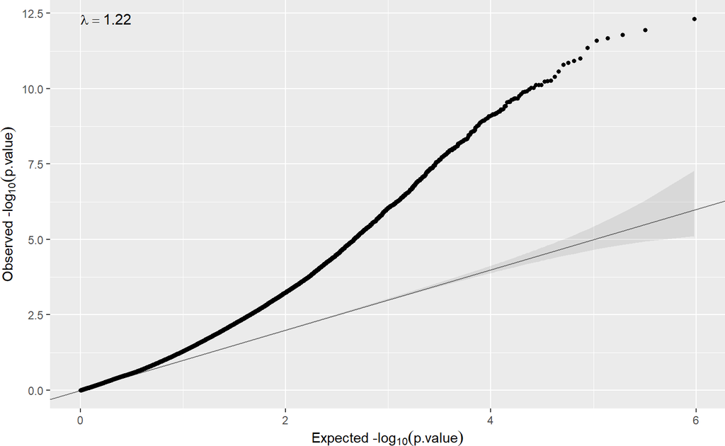

```r
qqplot(ans.meta$p.meta)
```

Here In some cases inflation can be observed, so that, correction for cell-type or surrogate variables must be performed. We describe how we can do that in the next two sections.

## 3.5 Adjusting for Surrogate Variables

The vast majority of omic studies require to control for unwanted variability. The surrogate variable analysis (SVA) can address this issue by estimating some hidden covariates that capture differences across individuals due to some artifacts such as batch effects or sample quality sam among others. The method is implemented in *SVA* package.

Performing this type of analysis using the `ds.lmFeature` function is not allowed since estimating SVA would require to implement a non-disclosive method that computes SVA from the different servers. This will be a future topic of the `dsOmicsClient`. NOTE that, estimating SVA separately at each server would not be a good idea since the aim of SVA is to capture differences mainly due to experimental issues among ALL individuals. What we can do instead is to use the `ds.limma` function to perform the analyses adjusted for SVA at each study.

```r
ans.sva <- ds.limma(model = ~ diagnosis + Sex,
                    Set = "methy",
                    sva = TRUE, annotCols = c("CHR", "UCSC_RefGene_Name"))
ans.sva
```

```
$study1
# A tibble: 481,868 x 9
   id            n    beta      SE     t  P.Value adj.P.Val
   <chr>     <int>   <dbl>   <dbl> <dbl>    <dbl>     <dbl>
 1 cg035381~   100 -0.0300 0.0106  -6.99 3.64e-10  0.000102
 2 cg247245~   100 -0.0397 0.00452 -6.88 6.12e-10  0.000102
 3 cg021567~   100 -0.0497 0.00947 -6.87 6.35e-10  0.000102
 4 cg238596~   100 -0.0498 0.00715 -6.79 9.36e-10  0.000113
 5 cg137728~   100 -0.0767 0.00697 -6.62 2.01e- 9  0.000168
 6 cg052138~   100 -0.0803 0.0160  -6.62 2.10e- 9  0.000168
 7 cg194060~   100 -0.0409 0.00779 -6.52 3.29e- 9  0.000201
 8 cg261524~   100 -0.0840 0.00947 -6.52 3.33e- 9  0.000201
 9 cg009799~   100 -0.0723 0.00539 -6.44 4.81e- 9  0.000242
10 cg276606~   100 -0.0514 0.00128 -6.43 5.03e- 9  0.000242
# ... with 481,858 more rows, and 2 more variables:
#   CHR <chr>, UCSC_RefGene_Name <chr>

$study2
# A tibble: 481,868 x 9
   id           n    beta      SE     t   P.Value adj.P.Val
   <chr>    <int>   <dbl>   <dbl> <dbl>     <dbl>     <dbl>
 1 cg03470~    90 -0.0502 0.0104  -6.41   7.30e-9   0.00352
 2 cg02293~    90 -0.0394 0.00372 -6.02   4.04e-8   0.00663
 3 cg24302~    90 -0.0370 0.0111  -5.87   7.90e-8   0.00663
 4 cg07664~    90 -0.0416 0.00719 -5.85   8.43e-8   0.00663
 5 cg16766~    90 -0.0436 0.00671 -5.83   9.38e-8   0.00663
 6 cg04046~    90 -0.100  0.0142  -5.81   9.90e-8   0.00663
 7 cg00848~    90 -0.0414 0.00836 -5.79   1.07e-7   0.00663
 8 cg08862~    90 -0.0289 0.00900 -5.79   1.10e-7   0.00663
 9 cg10850~    90 -0.0700 0.00445 -5.74   1.35e-7   0.00672
10 cg27098~    90 -0.0664 0.00156 -5.72   1.49e-7   0.00672
# ... with 481,858 more rows, and 2 more variables:
#   CHR <chr>, UCSC_RefGene_Name <chr>

attr(,"class")
[1] "dsLimma" "list"
```

Then, data can be combined meta-anlyzed as follows:

```r
ans.meta.sv <- metaPvalues(ans.sva)
ans.meta.sv
```

```
# A tibble: 481,868 x 4
   id           study1       study2   p.meta
   <chr>         <dbl>        <dbl>    <dbl>
 1 cg24302412 1.94e- 8 0.0000000790 5.37e-14
 2 cg01301319 8.29e- 9 0.000000769  2.14e-13
 3 cg05213896 2.10e- 9 0.00000763   5.25e-13
 4 cg02812891 1.07e- 8 0.00000153   5.37e-13
 5 cg00228891 5.61e- 8 0.000000301  5.53e-13
 6 cg12695465 5.90e- 9 0.00000360   6.90e-13
 7 cg13138089 6.16e- 9 0.00000571   1.12e-12
 8 cg24724506 6.12e-10 0.0000829    1.60e-12
 9 cg19406036 3.29e- 9 0.0000331    3.37e-12
10 cg16026647 2.82e- 7 0.000000449  3.89e-12
# ... with 481,858 more rows
```

The DataSHIELD session must by closed by:

```r
datashield.logout(conns)
```

# 4 Genomic data analysis: GWAS

Genomic data can be stored in different formats. [PLINK](http://zzz.bwh.harvard.edu/plink/) and [VCF](https://www.internationalgenome.org/wiki/Analysis/vcf4.0/) files are commonly used in genetic epidemiology studies. We have a GWAS example available at [BRGE data repository](https://github.com/isglobal-brge/brgedata) that aims to find SNPs associated with asthma. We have data stored in VCF (brge.vcf) with several covariates and phenotypes available in the file brge.txt (gender, age, obesity, smoking, country and asthma status). The same data is also available in PLINK format (brge.bed, brge.bim, brge.fam) with covariates in the file brge.phe.

## 4.1 Analysis with Bioconductor packages: example how to extend the resources

In order to deal with this type of data, we have extended the resources available at the *resourcer* package to VCF files. **NOTE**: PLINK files can be translated into VCF files using different pipelines. In R you can use *SeqArray* to get VCF files.

We use the Genomic Data Storage (GDS) format which efficiently manage VCF files into the R environment. This extension requires to create a Client and a Resolver function that are located into the *[dsOmics](https://github.com/isglobal-brge)* package. The client function uses `snpgdsVCF2GDS` function implemented in *SNPrelate* to coerce the VCF file to a GDS object. Then the GDS object is loaded into R as an object of class `GdsGenotypeReader` from *GWASTools* package that facilitates downstream analyses.

The opal API server allows to incorporate this new type of resource as illustrated in Figure 11.

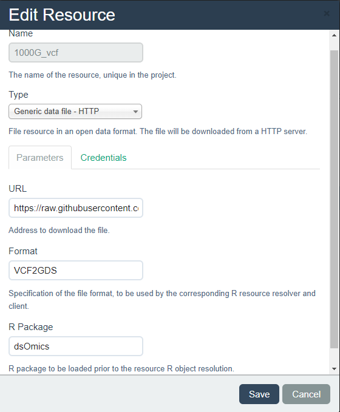

Figure 11: Description of how a VCF file can be added to the opal resources

It is important to notice that the URL should contain the tag `method=biallelic.only&snpfirstdim=TRUE` since these are required parameters of `snpgdsVCF2GDS` function. This is an example:

```
https://raw.githubusercontent.com/isglobal-brge/scoreInvHap/master/inst/extdata/example.vcf?method=biallelic.only&snpfirstdim=TRUE
```

In that case we indicate that only biallelic SNPs are considered (‘method=biallelic.only’) and that genotypes are stored in the individual-major mode, (i.e., list all SNPs for the first individual, and then list all SNPs for the second individual, etc) (‘snpfirstdim=TRUE’).

We have created a resource having the VCF file of our study on asthma as previously described. The name of the resource is `brge_vcf` the phenotypes are available in another resource called `brge` that is a .txt file. The GWAS analysis is then perform as follows

We first start by preparing login data

```r
builder <- newDSLoginBuilder()
builder$append(server = "study1", url = "https://opal-demo.obiba.org",
               user = "dsuser", password = "password",
               resource = "RSRC.brge_vcf")
logindata <- builder$build()

conns <- datashield.login(logins = logindata, assign = TRUE,
                          symbol = "res")
```

```r
datashield.assign.resource(conns, symbol = "vcf.res",
                           resource = list(study1 = "RSRC.brge_vcf"))
datashield.assign.expr(conns, symbol = "gds",
                       expr = quote(as.resource.object(vcf.res)))


datashield.assign.resource(conns, symbol = "covars.res",
                           resource = list(study1 = "RSRC.brge"))
datashield.assign.expr(conns, symbol = "covars",
                       expr = quote(as.resource.data.frame(covars.res)))
```

These are the objects available in the Opal server

```r
ds.ls()
```

```
$study1
$study1$environment.searched
[1] "R_GlobalEnv"

$study1$objects.found
[1] "covars"     "covars.res" "gds"        "res"
[5] "vcf.res"
```

We can use *dsBaseClient* functions to inspect the variables that are in the `covars` data.frame. The variables are

```r
ds.colnames("covars")
```

```
$study1
[1] "scanID"  "gender"  "obese"   "age"     "smoke"
[6] "country" "asthma"
```

The `asthma` variable has this number of individuals at each level (0: controls, 1: cases)

```r
ds.table("covars$asthma")
```

```
 Data in all studies were valid

Study 1 :  No errors reported from this study
```

```
$output.list
$output.list$TABLE_rvar.by.study_row.props
             study
covars$asthma 1
            0 1
            1 1

$output.list$TABLE_rvar.by.study_col.props
             study
covars$asthma         1
            0 0.6864187
            1 0.3135813

$output.list$TABLE_rvar.by.study_counts
             study
covars$asthma    1
            0 1587
            1  725

$output.list$TABLES.COMBINED_all.sources_proportions
covars$asthma
    0     1
0.686 0.314

$output.list$TABLES.COMBINED_all.sources_counts
covars$asthma
   0    1
1587  725


$validity.message
[1] "Data in all studies were valid"
```

There may be interest in only studying certain genes, for that matter, the loaded VCF resource can be subsetting as follows

```r
genes <- c("A1BG","A2MP1")
ds.getSNPSbyGen("gds", genes)
```

The previous code will over-write the VCF with the SNPs corresponding to the selected genes, if the intention is to perform studies with both the complete VCF and a subsetted one, the argument `name` can be used to create a new object on the server with the subsetted VCF, preserving the complete one.

```r
genes <- c("A1BG","A2MP1")
ds.getSNPSbyGen("gds", genes = genes, name = "subset.vcf")
```

Then, an object of class `GenotypeData` must be created at the server side to perform genetic data analyses. This is a container defined in the *GWASTools* package for storing genotype and phenotypic data from genetic association studies. By doing that we will also verify whether individuals in the GDS (e.g VCF) and covariates files have the same individuals and are in the same order. This can be performed by

```r
ds.GenotypeData(x='gds', covars = 'covars', columnId = 1, sexId = 2, male_encoding = "2", female_encoding = "1", newobj.name = 'gds.Data')
```

Before performing the association analyses, quality control (QC) can be performed to the loaded data. Three methodologies are available; 1) Principal Component Analysis (PCA) of the genomic data, 2) Hardy-Weinberg Equilibrium (HWE) testing and 3) Allelic frequency estimates. The QC methods 2 and 3 have as inputs a *GenotypeData* object, created with a covariates file that has a gender column; while method 1 has as input a *VCF*.

To perform the PCA, a pruning functionality is built inside so that redundant SNPs are discarted (there is an extra argument `ld.threshold` which controls the pruning, more information about it at the [SNPRelate documentation](https://rdrr.io/bioc/SNPRelate/man/snpgdsLDpruning.html)), speeding up the execution time

```r
pca <- ds.PCASNPS("gds", prune = TRUE)
plotPCASNPS(pca)
```

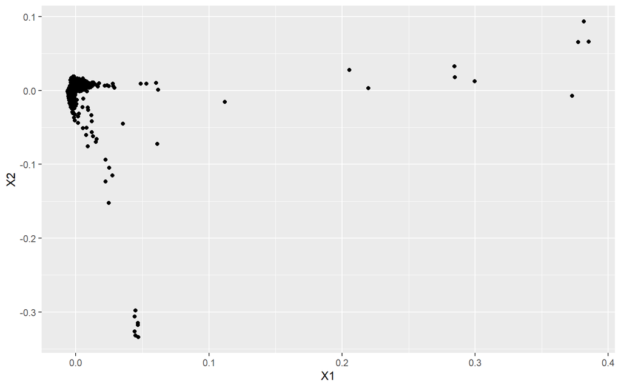

[figure not shown]

[figure not shown]

```r
ds.table1D("covars$gender")$counts
```

```
      covars$gender
1              1215
2              1097
Total          2312
```

The HWE test can be performed to selected chromosomes using the argument `chromosomes`, only the autosomes can be selected when performing a HWE test, the encoding of the autosomes present on the object can be fetched with

```r
ds.genoDimensions('gds.Data')$chromosomes
```

Therefore, HWE can be performed by:

```r
ds.exactHWE("gds.Data", chromosome = "20")
```

```
$study1
# A tibble: 2,384 x 8
   rs     chr     nAA   nAB   nBB   MAF minor.allele   pval
   <chr>  <chr> <dbl> <dbl> <dbl> <dbl> <chr>         <dbl>
 1 rs613~ 20      123   815  1351 0.232 A            1
 2 rs603~ 20      114   782  1410 0.219 A            0.670
 3 rs603~ 20      286  1013  1009 0.343 A            0.197
 4 rs608~ 20      384  1085   821 0.405 A            0.435
 5 rs607~ 20      496  1131   679 0.460 A            0.557
 6 rs169~ 20      358  1100   841 0.395 A            1.00
 7 rs448~ 20      330  1087   888 0.379 A            0.965
 8 rs608~ 20      309  1070   927 0.366 A            1
 9 rs209~ 20       20   446  1840 0.105 A            0.268
10 rs605~ 20      546  1088   656 0.476 A            0.0237
# ... with 2,374 more rows

attr(,"class")
[1] "dsexactHWE" "list"
```

The same test can be conducted only for the control individuals (on this example taking the asthma covariates columnas as a cas/control) by:

```r
ds.exactHWE("gds.Data", chromosome = "20", controls = TRUE, controls_column = "asthma")
```

```
$study1
# A tibble: 2,384 x 8
   rs      chr     nAA   nAB   nBB   MAF minor.allele  pval
   <chr>   <chr> <dbl> <dbl> <dbl> <dbl> <chr>        <dbl>
 1 rs6139~ 20       90   559   927 0.234 A            0.624
 2 rs6038~ 20       76   532   975 0.216 A            0.767
 3 rs6039~ 20      200   708   677 0.350 A            0.473
 4 rs6086~ 20      266   761   548 0.410 A            0.958
 5 rs6074~ 20      358   770   457 0.469 A            0.338
 6 rs1699~ 20      245   767   567 0.398 A            0.600
 7 rs4482~ 20      224   760   599 0.382 A            0.523
 8 rs6082~ 20      215   736   633 0.368 A            0.957
 9 rs2092~ 20       13   308  1260 0.106 A            0.285
10 rs6051~ 20      382   758   431 0.484 A            0.189
# ... with 2,374 more rows

attr(,"class")
[1] "dsexactHWE" "list"
```

Similarly, allele frequencies estimates can be estimated by:

```r
ds.alleleFrequency("gds.Data")
```

```
$study1
# A tibble: 99,289 x 8
   rs           M       F     all   n.M   n.F     n     MAF
   <chr>    <dbl>   <dbl>   <dbl> <dbl> <dbl> <dbl>   <dbl>
 1 MitoC~ 0.0147  1.5 e-2 1.49e-2  1086  1200  2286 1.49e-2
 2 MitoG~ 0.00276 8.37e-4 1.75e-3  1087  1195  2282 1.75e-3
 3 MitoG~ 0.00548 3.30e-3 4.33e-3  1095  1212  2307 4.33e-3
 4 MitoT~ 0.00868 1.24e-2 1.06e-2  1095  1213  2308 1.06e-2
 5 MitoC~ 0       1.65e-3 8.66e-4  1095  1214  2309 8.66e-4
 6 MitoT~ 0.0754  7.12e-2 7.32e-2  1094  1208  2302 7.32e-2
 7 MitoA~ 0.00913 6.60e-3 7.80e-3  1095  1213  2308 7.80e-3
 8 MitoG~ 0.00274 2.48e-3 2.61e-3  1093  1209  2302 2.61e-3
 9 MitoA~ 0.181   1.82e-1 1.81e-1  1071  1188  2259 1.81e-1
10 MitoT~ 0       1.65e-3 8.68e-4  1094  1210  2304 8.68e-4
# ... with 99,279 more rows

attr(,"class")
[1] "dsalleleFrequency" "list"
```

In the future, more functions will be created to perform quality control (QC) for both, SNPs and inviduals.

Association analysis for a given SNP is performed by simply

```r
ds.glmSNP(snps.fit = "rs11247693", model = asthma ~ gender + age, genoData='gds.Data')
```

```
             Estimate Std. Error   p-value    n     p.adj
rs11247693 -0.1543215  0.2309585 0.5040196 2311 0.5040196
attr(,"class")
[1] "dsGlmSNP" "matrix"   "array"
```

The analysis of all available SNPs is performed when the argument `snps.fit` is missing. The function performs the analysis of the selected SNPs in a single repository or in multiple repositories as performing pooled analyses (it uses `ds.glm` DataSHIELD function). As in the case of transcriptomic data, analyzing all the SNPs in the genome (e.g GWAS) will be high time-consuming. We can adopt a similar approach as the one adopted using the *limma* at each server. That is, we run GWAS at each repository using specific and scalable packages available in R/Bioc. In that case we use the *GWASTools* and *GENESIS* packages. The complete pipeline is implemented in this function

```r
ans.bioC <- ds.GWAS('gds.Data', model=asthma~age+country)
```

This close the DataSHIELD session

```r
datashield.logout(conns)
```

## 4.2 GWAS with PLINK

Here we illustrate how to perform the same GWAS analyses on the asthma using PLINK secure shell commands. This can be performed thanks to the posibility of having ssh resources as described here.

It is worth to notice that this workflow and the new R functions implemented in *dsOmicsClient* could be used as a guideline to carry out similar analyses using existing analysis tools in genomics such as IMPUTE, SAMtools or BEDtools among many others.

We start by assigning login resources

```r
  library(DSOpal)
  library(dsBaseClient)
  library(dsOmicsClient)
  builder <- newDSLoginBuilder()
  builder$append(server = "study1", url = "https://opal-demo.obiba.org",
                 user = "dsuser", password = "password",
                 resource = "RSRC.brge_plink")
  logindata <- builder$build()
```

Then we assign the resource to a symbol (i.e. R object) called `client` which is a ssh resource

```r
  conns <- datashield.login(logins = logindata, assign = TRUE,
                            symbol = "client")
  ds.class("client")
```

```
$study1
[1] "SshResourceClient"     "CommandResourceClient"
[3] "ResourceClient"        "R6"
```

Now, we are ready to run any PLINK command from the client site. Notice that in this case we want to assess association between the genotype data in bed format and use as phenotype the variable ‘asthma’ that is in the file ‘brge.phe’ in the 6th column. The sentence in a PLINK command would be (NOTE: we avoid –out to indicate the output file since the file will be available in R as a tibble).

```
  plink --bfile brge --logistic --pheno brge.phe --mpheno 6 --covar brge.phe --covar-name gender,age
```

The arguments must be encapsulated in a single character without the command ‘plink’

```r
  plink.arguments <- "--bfile brge --logistic --pheno brge.phe --mpheno 6 --covar brge.phe --covar-name gender,age"
```

the analyses are then performed by

```r
  ans.plink <- ds.PLINK("client", plink.arguments)
```

The object `ans.plink` contains the PLINK results at each server as well as the outuput provided by PLINK

```r
  lapply(ans.plink, names)
```

```
$study1
[1] "results"   "plink.out"
```

```r
  head(ans.plink$study1$results)
```

```
# A tibble: 6 x 9
    CHR SNP       BP A1    TEST  NMISS    OR   STAT       P
  <dbl> <chr>  <dbl> <chr> <chr> <dbl> <dbl>  <dbl>   <dbl>
1     0 MitoC~  3993 T     ADD    2286 0.752 -1.33  1.82e-1
2     0 MitoC~  3993 T     gend~  2286 0.742 -3.27  1.07e-3
3     0 MitoC~  3993 T     age    2286 1.00   0.565 5.72e-1
4     0 MitoG~  4821 A     ADD    2282 2.68   1.71  8.79e-2
5     0 MitoG~  4821 A     gend~  2282 0.740 -3.31  9.40e-4
6     0 MitoG~  4821 A     age    2282 1.00   0.465 6.42e-1
```

```r
  ans.plink$study$plink.out
```

[output not shown]

[output cut: 70 more lines]

[output not shown]

We can compare the p-values obtained using PLINK with Bioconductor-based packages for the top-10 SNPs as follows:

```r
  library(tidyverse)
  # get SNP p.values (additive model - ADD)
  res.plink <- ans.plink$study1$results %>% filter(TEST=="ADD") %>%
    arrange(P)
  # compare top-10 with Biocoductor's results
  snps <- res.plink$SNP[1:10]
  plink <- res.plink %>% filter(SNP%in%snps) %>% dplyr::select(SNP, P)
  bioC <- ans.bioC$study1 %>% filter(rs%in%snps) %>% dplyr::select(rs, p.value)
  left_join(plink, bioC, by=c("SNP" = "rs"))
```

```
# A tibble: 10 x 3
   SNP                 P     p.value
   <chr>           <dbl>       <dbl>
 1 rs2267914  0.00000151 0.000000809
 2 rs6097326  0.00000424 0.00000642
 3 rs7153     0.00000440 0.00000508
 4 rs3732410  0.00000817 0.00000940
 5 rs7995146  0.0000170  0.0000195
 6 rs6495788  0.0000213  0.0000278
 7 rs1602679  0.0000268  0.0000264
 8 rs11055608 0.0000270  0.0000161
 9 rs7098143  0.0000313  0.0000214
10 rs7676164  0.0000543  0.0000537
```

As expected, the p-values are in the same order of magnitud having little variations due to the implemented methods of each software.

We can do the same comparisons of minor allele frequency (MAF) estimation performed with Bioconductor and PLINK. To this end, we need first to estimate MAF using PLINK

```r
  plink.arguments <- "--bfile brge --freq"
  ans.plink2 <- ds.PLINK("client", plink.arguments)
  maf.plink <- ans.plink2$study1$results

  plink <- maf.plink %>% filter(SNP%in%snps) %>% dplyr::select(SNP, MAF)
  bioC <- ans.bioC$study1 %>% filter(rs%in%snps) %>% dplyr::select(rs, freq)
  left_join(plink, bioC, by=c("SNP" = "rs"))
```

```
# A tibble: 10 x 3
   SNP           MAF   freq
   <chr>       <dbl>  <dbl>
 1 rs7153     0.256  0.256
 2 rs3732410  0.254  0.254
 3 rs7676164  0.304  0.304
 4 rs1602679  0.101  0.101
 5 rs7098143  0.210  0.210
 6 rs11055608 0.446  0.446
 7 rs7995146  0.0527 0.0527
 8 rs6495788  0.267  0.267
 9 rs2267914  0.104  0.104
10 rs6097326  0.125  0.125
```

This close the DataSHIELD session

```r
  datashield.logout(conns)
```

# 5 Acknowledgments

JRG want to thank Deroshan Padotan for having worked on a preliminary version of `dsOmicsClient` package developed before the `resourcer` package was created. We also thank Demetris Avraam for his feedback while programming DataSHIELD functions and writing the vignette. Leire Abarrategui is acknowledged for implementing RNA-seq data analysis using DESeq2 and edgeR. Xavier Escribà is also acknowledged for the implementation of several functions to summarize and perform quality control of SNP data.

# References

Wilson, Rebecca, Oliver Butters, Demetris Avraam, James Baker, Jonathan Tedds, Andrew Turner, Madeleine Murtagh, and Paul Burton. 2017. “DataSHIELD – New Directions and Dimensions.” *Data Science Journal* 16 (0): 21. https://doi.org/10.5334/dsj-2017-021.